# Assignment - Week 09

Yara Roth

2026-05-10

# Setup

```r
suppressPackageStartupMessages({
  library(GenomicRanges)
  library(epiwraps)
  library(ggplot2)
  library(rGREAT)
})
library(rstudioapi)
setwd(dirname(rstudioapi::getActiveDocumentContext()$path))
dir.create("data")
```

# Download

```r
options(timeout = 6000)
download.file("https://ethz-ins.org/content/clustering_assignment.zip", "data/clustering_assignment.zip")
unzip("data/clustering_assignment.zip", exdir="data")
list.files()
```

## Prepare regions

```r
peaks <- list.files(path="data",pattern="bed$", full.names=TRUE)
# we first import the peaks
peaks <- lapply(peaks, rtracklayer::import.bed)
# we'll focus on the high-quality peaks
peaks <- lapply(peaks, FUN=function(x) x[x$score>800])
# we get the union of non-redundant regions
regions <- reduce(unlist(GRangesList(peaks)))
```

## Prepare the tracks

```r
tracks <- list.files(path="data", pattern="bw$", full.names=TRUE)
```

## Heatmap signal signal matrix

Now we can look at the signals of Creb1, Creb3 and Creb3L in the heatmap.

```r
ese <- signal2Matrix(tracks, regions, extend=2000)
```

```
## Reading data/Creb1.bw
```

```
## Reading data/Creb3.bw
```

```
## Reading data/Creb3L1.bw
```

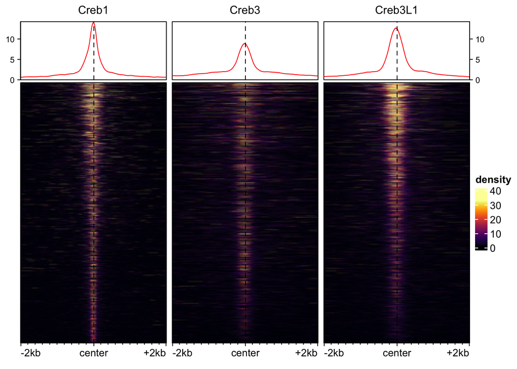

```r
plotEnrichedHeatmaps(ese)
```

```r
ese2 <- ese[1:1000,]
```

Here the signals of the three TF look very similar.

Now we can look at the signals again using the implemented clusering of the plotEnrichedHeatmaps function. This i smainly used for exploratory purposes, as the regions are not assigned to discrete clusters.

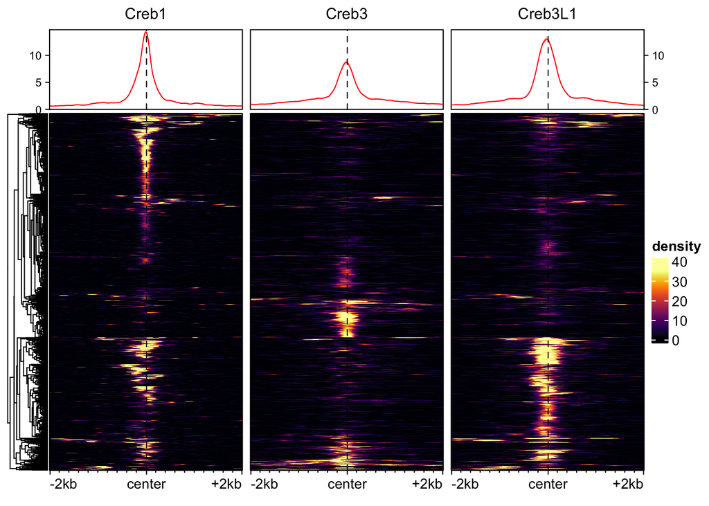

```r
ese2 <- ese[1:1000,]
plotEnrichedHeatmaps(ese2, cluster_rows = TRUE, show_row_dend=TRUE )
```

In a next step we can perform clustering independently:

```r
set.seed(10)
cl <- clusterSignalMatrices(ese, k=4)
```

```
##   ~66% of the variance explained by clusters
```

```r
table(cl)
```

```
## cl
##   1   2   3   4
## 720 901 450 198
```

```r
head(cl)
```

```
## [1] 1 2 2 2 2 2
## Levels: 1 2 3 4
```

```r
length(cl)
```

```
## [1] 2269
```

```r
nrow(ese)
```

```
## [1] 2269
```

```r
# to make sure the cluster labels stay associated with the corresponding regions/rows
# even if we manipulate the object, put them inside the rowData of the object:
rowData(ese)$cluster <- cl
head(rowData(ese))
```

```
## DataFrame with 6 rows and 1 column
##                     cluster
##                    <factor>
## chr1:778487-779069        1
## chr1:904436-904985        2
## chr1:941785-942096        2
## chr1:943126-943501        2
## chr1:959088-959463        2
## chr1:961148-961904        2
```

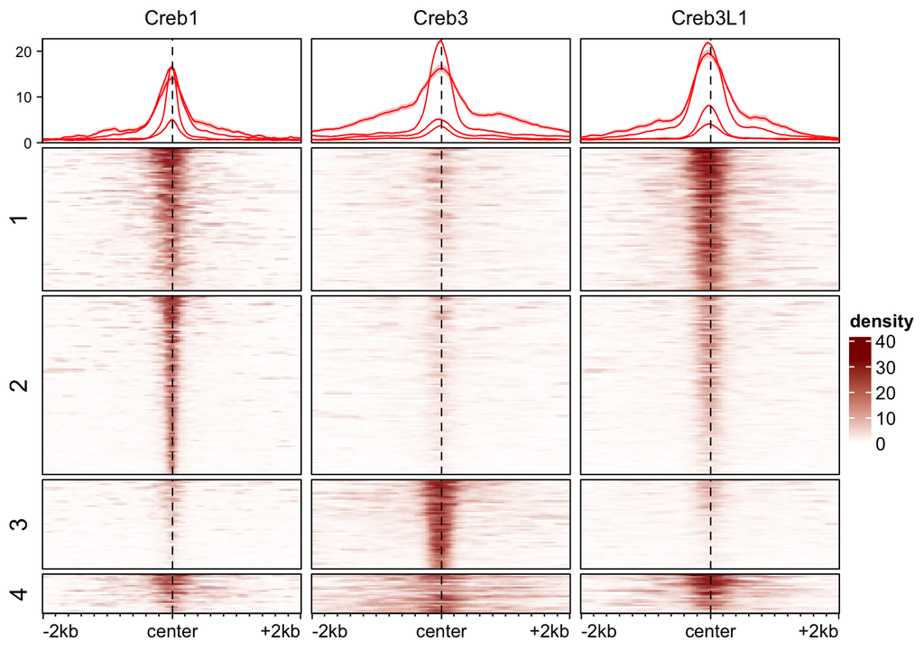

```r
plotEnrichedHeatmaps(ese, row_split=rowData(ese)$cluster,
                     colors=c("white","darkred"))
```

Next we need to decide on the number of clusters that we are going to use. Therefore we can look at the number of clusters and the variance that they explain:

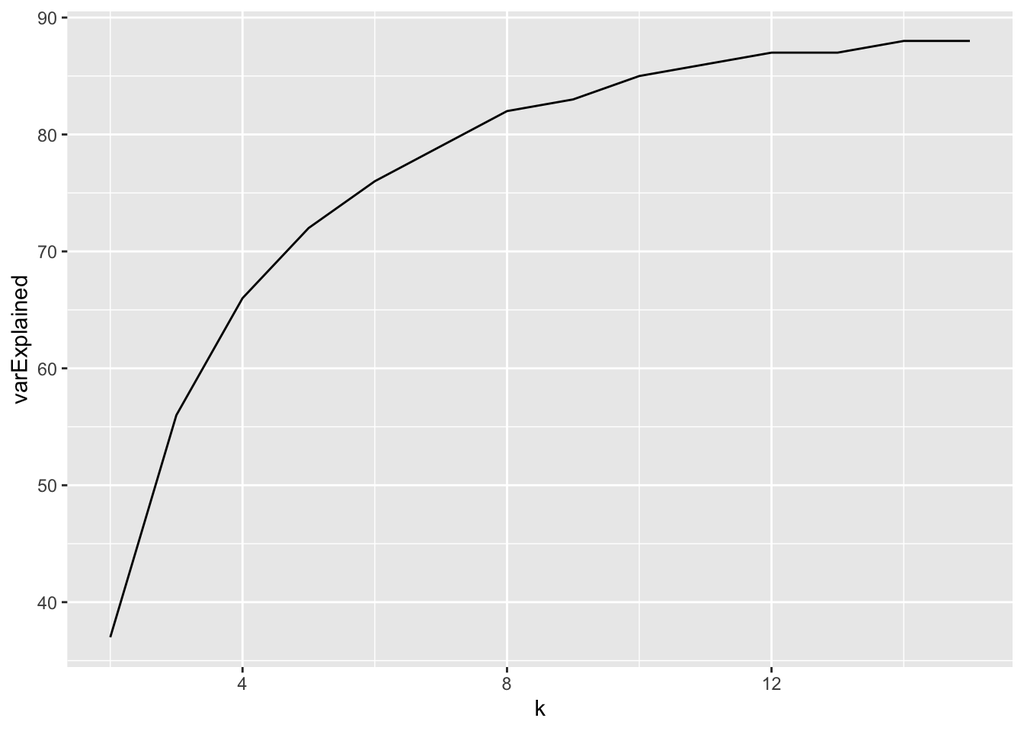

```r
cl2 <- clusterSignalMatrices(ese, k=2:15)
ggplot(cl2$varExplained, aes(k, varExplained)) + geom_line()
```

As discussed in the lecture it is possible that some clusers mainly differ due to differences in the signal magnitude -> this could result from technical artifacts.  
Therefore we can normalize the signal intensity before performing the clustering -> perform clustering using relative signals instead:

```r
set.seed(10)
cl <- clusterSignalMatrices(ese, k=6, scaleRows = TRUE)
```

```
##   ~92% of the variance explained by clusters
```

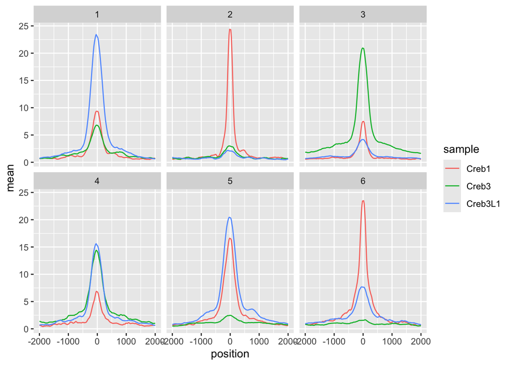

```r
d <- meltSignals(ese, splitBy=cl)
ggplot(d, aes(position, mean, colour=sample)) + geom_line() + facet_wrap(~split)
```

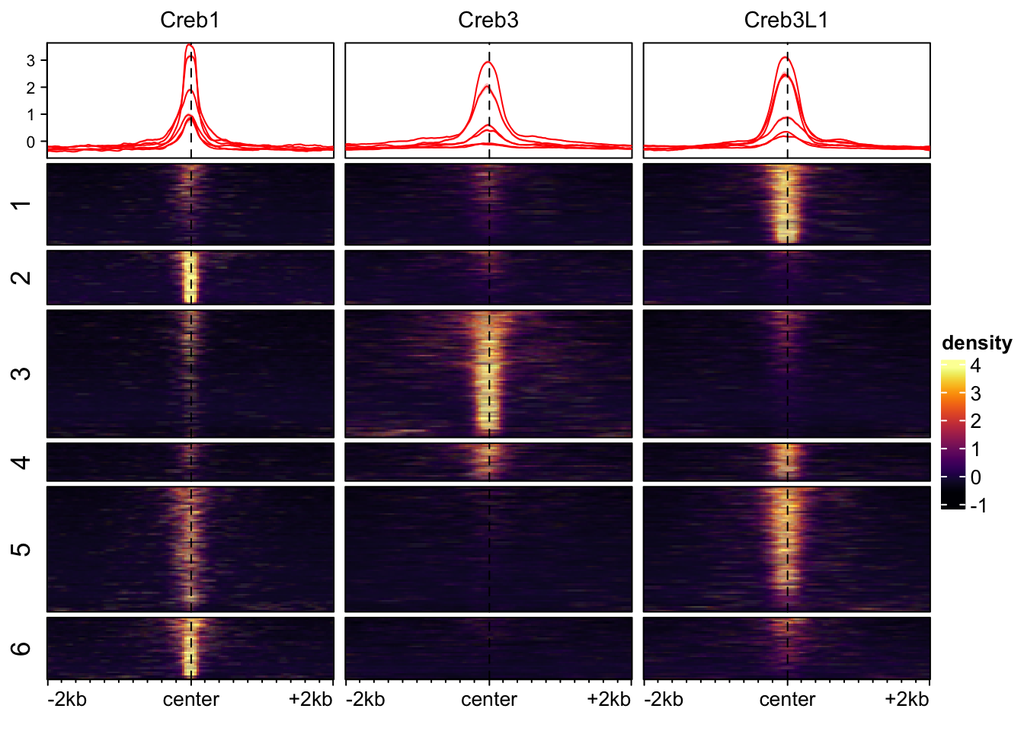

```r
plotEnrichedHeatmaps(ese, row_split = cl, scale_rows = "global")
```

With this clustering we can now clearly see that there is a difference in the binding of these three TF. There are regions where mainly Creb1, Creb3 or Creb3L bind individually.  
We also see that there are regions where Creb3 and Creb3L bind together and regions where Creb1 and Creb3L bind together.